## Homework 9

#### Due Friday, April 2, 11:59 PM CT

### 1

- Read in the `chimpanzee.csv` data file.
- Consider only those trials with a partner.
- Make an assumption that there is a universal $p_{\text{partner}}$ representing the probability any chimpanzee would make a prosocial choice in a single trial under the experimental conditions we have been examining.
- Assume that all trials are independent.

*(a)* Under these assumptions, write down a statistical model for $X_1$, the total number of prosocial choices made with a partner present in this experiment.

Chimpanzees made pro-social choice 359 times out of 610 when the partner is present.

Model:

$$X_1 \mid p \sim \text{Binomial}(n,p_{\text{partner}})$$
Hypothesis:

- $H_0: p = 0.5$
- $H_a: p \neq 0.5$

Test statistic is $X_1$.

If the null hypothesis is true, then

$$X_1 \sim \text{Binomial}(610,0.5)$$

*(b)* Test the hypothesis that $p_{\text{partner}} = 0.5$ versus the two-sided alternative. Report a p-value.

```r
chimp <- read_csv("../../data/chimpanzee.csv")%>%
  mutate(with_partner = case_when(
    partner == "none" ~ "No Partner",
    TRUE ~ "Partner"))

df<-chimp%>%
  filter(with_partner %in% "Partner")%>%
  summarize(pro_total = sum(prosocial),
         self_total = sum(selfish),
         total = pro_total+self_total,
         p = pro_total/total)
df
```

```
## # A tibble: 1 x 4
##   pro_total self_total total     p
##       <dbl>      <dbl> <dbl> <dbl>
## 1       359        251   610 0.589
```

```r
##two-sided alternative
tol <- 1.0e-07
x <- 0:df$total
x_extreme <- x[dbinom(x,df$total,0.5) < dbinom(df$self_total,df$total,0.5) + tol]
p_value <- sum(dbinom(x_extreme,df$total,0.5))
p_value
```

```
## [1] 1.405895e-05
```

*(c)* Create a graph that shows the sampling distribution of $X_1$ under the null hypothesis and indicates (with different colors and/or lines) how the p-value relates to the graph.

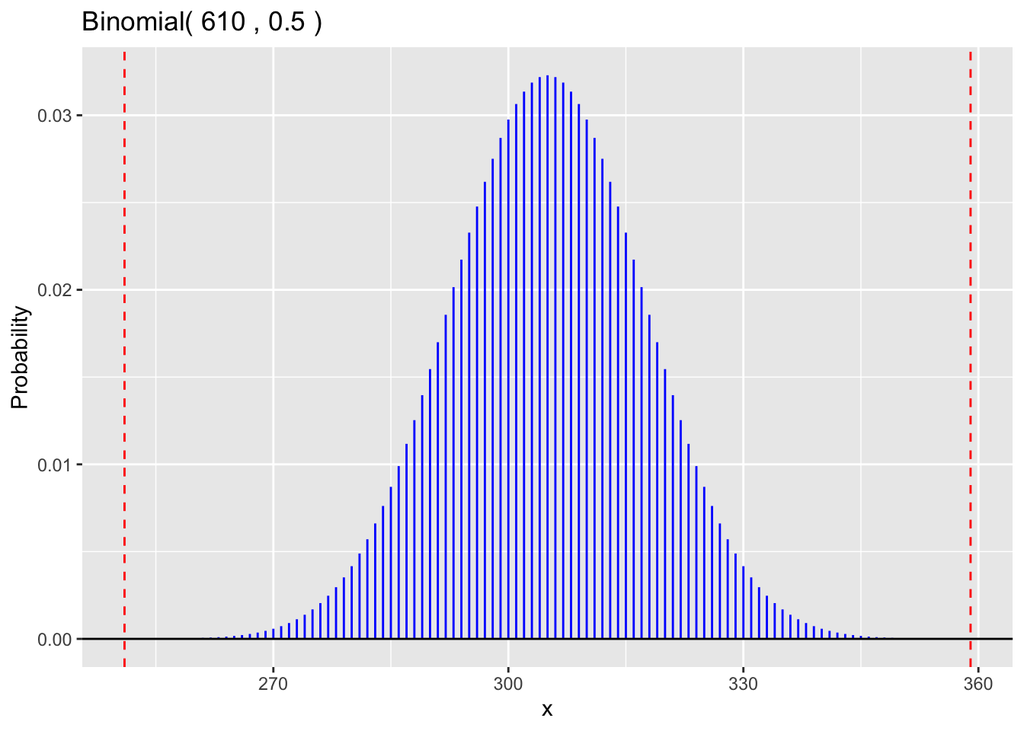

```r
n = df$total

gbinom(n,0.5,scale=T)+
  geom_vline(xintercept = df$pro_total, color="red", linetype = "dashed")+
  geom_vline(xintercept = n*0.5+(n*0.5-df$pro_total), color="red", linetype = "dashed")
```

*(d)* Interpret the results of the hypothesis test in context.

Since p-value (0.0000140589) < 0.01 which is highly statistically significant, it is sufficient enough to reject the null hypothesis. There is strong evidence that the null hypothesis is false and that the true value of $p$ is closer to 359/610. There is a very strong evidence that ($p \approx 0.0000140589$, two-sided binomial test) chimpanzees will make prosocial choice more than half of the time.

### 2

Repeat the previous problem, but use the data for all trials **without** a partner for an assumed universal parameter $p_{\text{no partner}}$, using a statistical model for $X_2$, the total number of prosocial choices made without a partner present in the experiment.

Chimpanzees made pro-social choice 83 times out of 180 when the partner is not present.

Model:

$$X_2 \mid p \sim \text{Binomial}(n,p_{\text{no partner}})$$
Hypothesis:

- $H_0: p = 0.5$
- $H_a: p \neq 0.5$

Test statistic is $X_2$.

If the null hypothesis is true, then

$$X_2 \sim \text{Binomial}(180,0.5)$$

```r
df2<-chimp%>%
  filter(with_partner %in% "No Partner")%>%
  summarize(pro_total = sum(prosocial),
         self_total = sum(selfish),
         total = pro_total+self_total,
         p = pro_total/total)
df2
```

```
## # A tibble: 1 x 4
##   pro_total self_total total     p
##       <dbl>      <dbl> <dbl> <dbl>
## 1        83         97   180 0.461
```

```r
##two-sided alternative
tol <- 1.0e-07
x2 <- 0:df2$total
x_extreme2 <- x[dbinom(x2,df2$total,0.5) < dbinom(df2$pro_total,df2$total,0.5) + tol]
p_value2 <- sum(dbinom(x_extreme2,df2$total,0.5))
p_value2
```

```
## [1] 0.3325791
```

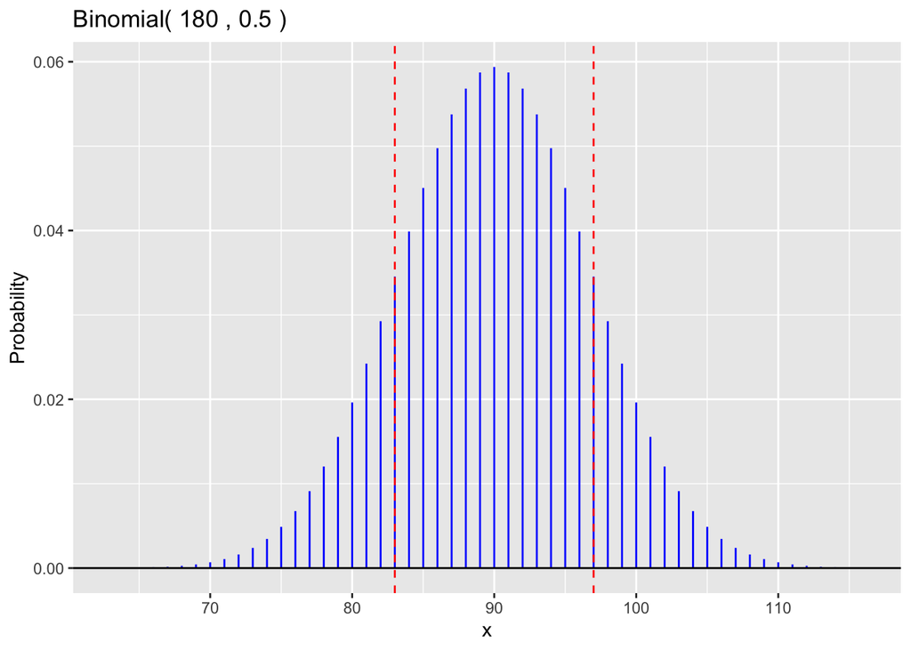

```r
n2 <- df2$total

gbinom(n2,0.5,scale=T)+
  geom_vline(xintercept = df2$pro_total, color="red", linetype = "dashed")+
  geom_vline(xintercept = n2*0.5+(n2*0.5-df2$pro_total), color="red", linetype = "dashed")
```

### 3

State two criticisms of the assumptions made for the previous two hypothesis tests where reality may differ from the assumptions, possibly leading to misleading conclusions.

- In reality, each trials may not be independent.
- The prosocial choices in a single trial cannot be applied to the universal prosocial choices of all chimpanzee, due to the small sample size conducted.

### 4

In questions 1 and 2, we considered two population proportions: $p_{\text{partner}}$ and $p_{\text{no partner}}$. It is sometimes of interest to estimate the *difference* in sample proportions rather than just the individual population proportions. Confidence intervals can be defined for this purpose.

*(a)* Using the Wald estimates, define an 80% confidence for the difference in the population proportions $p_{\text{partner}} - p_{\text{no partner}}$.

```r
df3<-chimp%>%
  group_by(with_partner)%>%
  summarize(pro_total = sum(prosocial),
         self_total = sum(selfish),
         n = pro_total+self_total,
         p_hat = pro_total/n,
         se = sqrt(p_hat*(1-p_hat)/(n)))

est_c_diff <- df3$p_hat[2]-df3$p_hat[1]
se_c_diff <- sqrt(df3$se[2]^2 + df3$se[1]^2)
z <- abs(qnorm((1-0.8)/2))
ci_c_diff<-est_c_diff + c(-1,1)*z*se_c_diff
ci_c_diff
```

```
## [1] 0.0733831 0.1814439
```

*(b)* Interpret the estimated confidence interval in context.